# Introduction to Python for Social Science

# EXERCISE 5: VISUALIZATION

Visualize the variable that contains whether the respondent voted last national election 'vote'.Group the visualization by highest level of education, Denmark 'edlvddk'

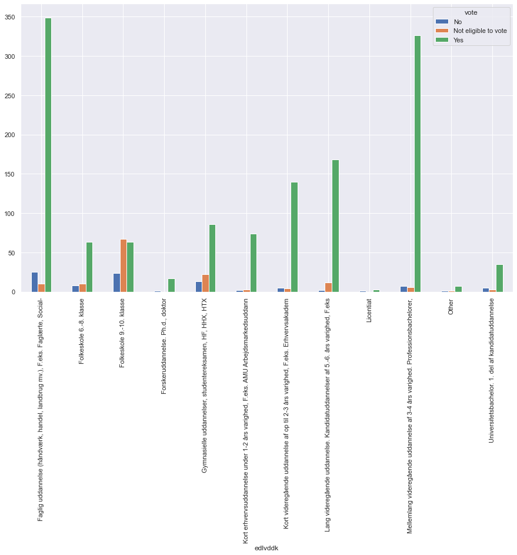

```python
groupeded_ess = ess.groupby(['edlvddk'])
groupeded_ess['vote'].value_counts().unstack('vote').plot.bar()
```

# Writing and reading data

Pandas supports exporting DataFrames as various files, including:

- .csv (comma-separated values)
- .xlsx (excel)
- .dta (Stata)

## Exporting data with pandas

Files are created using the methods `to_csv()`, `to_excel` and `to_stata` respectively.

```python
ess.to_csv('my_ess.csv')
ess.to_stata('my_ess.dta')
```

## Reading a simple csv file

The method `.read_csv` can be used to read a .csv-file as a dataframe.

Note that unless you specify an index, one will be automatically generated.

```python
ess_new = pd.read_csv('my_ess.csv', index_col=0)
ess_new.head()
```

[output not shown]

# EXERCISE 6: WRITE AND READ DATA

1. Save your ess data as a .csv
2. Read your data file as a dataframe - does it look right?